# Ch3

##### **CSPB 4830 - Special Topics: Coding Calculus**

### **Week #3 Workbook**

**Stephen Enriquez (@sten8791)**

**Chapter 3 Activities:**

This week we explore the derivative as a function and at a point.  
Be concise and ALSO be sure to include some explanations and context in addition to just your answers – i.e. does your answer make sense if someone reads it without the question?

We are exploring numerically AND geometrically; however, we are not using the typical formulas for derivatives.

First, we focus on numerical definitions of the derivative.

1. Try no. 1 page 115 as a warm-up. Then submit one of the examples no. 2 page 115. You can write code or use something like Desmos.com. Submit a single example with a sequence of both the line segments and the values. Make it look good!
2. Use a computer microscope to determine the following values, correct to one decimal place. Obtain estimates using a sequence of windows, and shrink the field of view until the first two decimal places stabilize. Show all the estimates you constructed in each sequence.
- a) f′(1) where f(x) = x^4 −8x.

Let's find f'(1), the rate of change of *f* when x = 1. We need to zoom in on the graph of f at the point below, taking successively smaller sequence of windows.

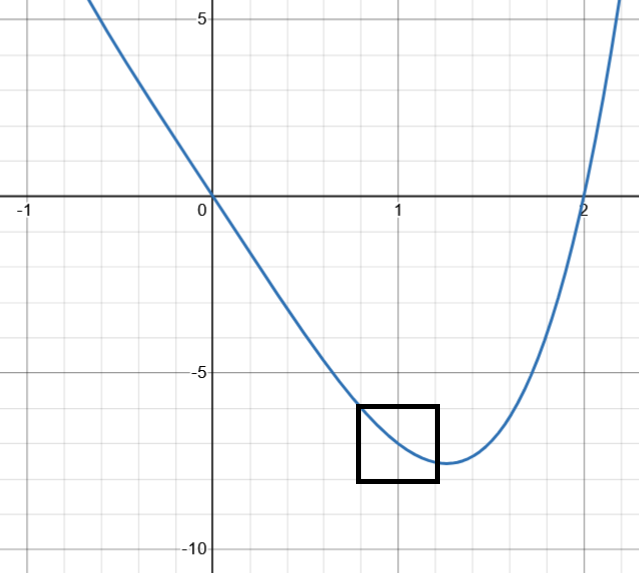

Let's start with a window of ∆x = 0.2:

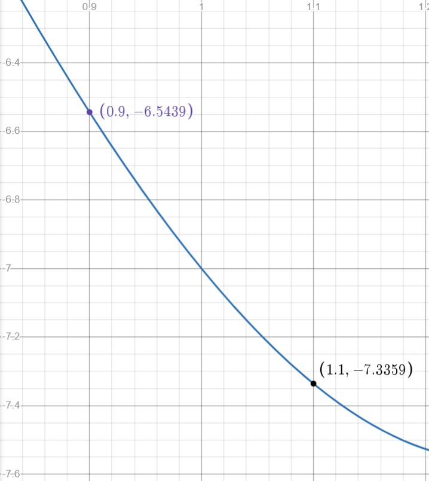

We can zoom in further to a window of ∆x = 0.02:

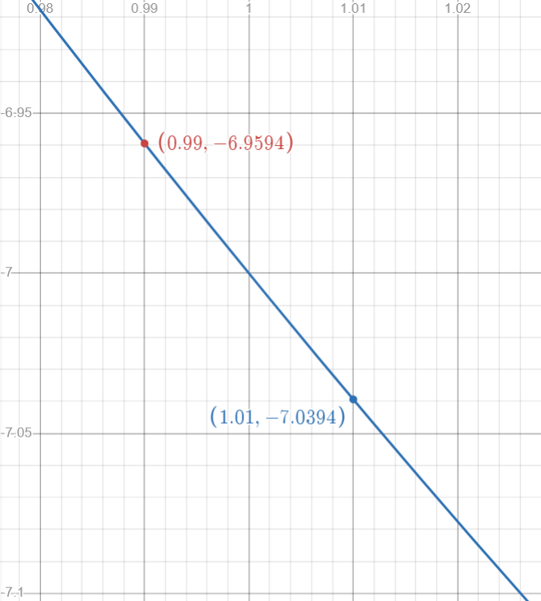

Furthermore, with an even tighter window of ∆x = 0.002:

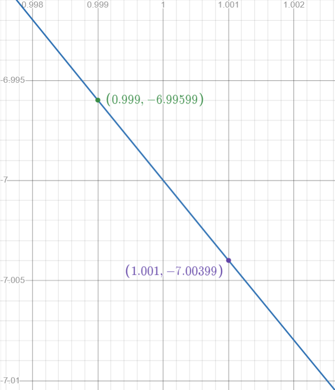

And finally, with a window of ∆x = 0.0002:

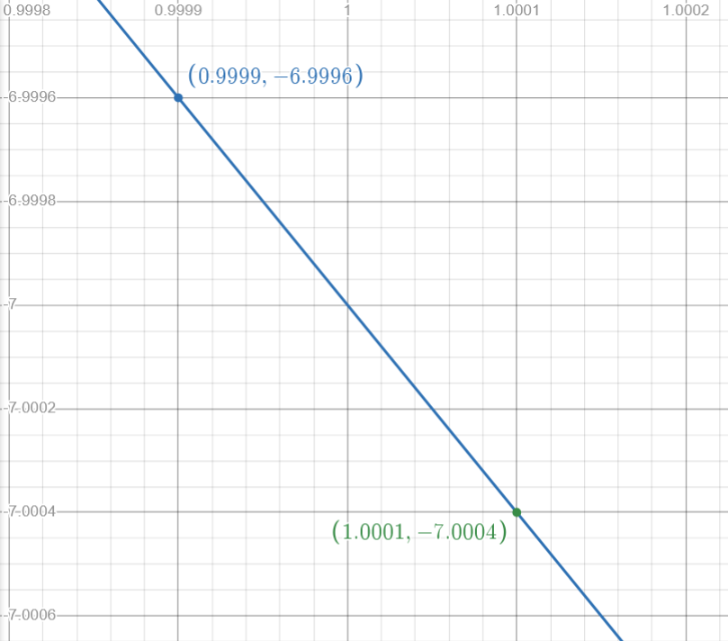

The following table gives the slope ∆y/∆x of the line that appears in each of the last four windows in the sequence:

| ∆x | ∆y | ∆y / ∆x |
| --- | --- | --- |
| 0.2 | -0.79200000 | -3.96000000 |
| 0.02 | -0.07999199 | -3.99959999 |
| 0.002 | -0.00799999 | -3.99999600 |
| 0.0002 | -0.00079999 | -3.99999996 |

The slopes ∆y/∆x in the table vary depending on the size of the window we are using. The table does show us that the more we magnify, the more the slopes get closer and closer to a definite value. Under successive magnifications, it appears that the first 4 digits of ∆y/∆x have stabilized.

2. no. 10 pp 118/119. Be sure to give examples/counter examples. Part d) is SUPER important. This is related to a classic proof!
10. True or false. If you think a statement is true, give your reason; if you think a statement is false, give a counterexample—i.e., an example that shows why it must be false.

a) If g′(t) is positive for all t, we can conclude that g(214) is positive.

False. A counter example would be the function g(t) = t - 215.

The slope for this function would be: ∆g / ∆t = 1.0 / 1.0 = 1.0

Thus, g'(t) is positive. However, as we can see below, g(214) is negative, thus the statement is **false**.

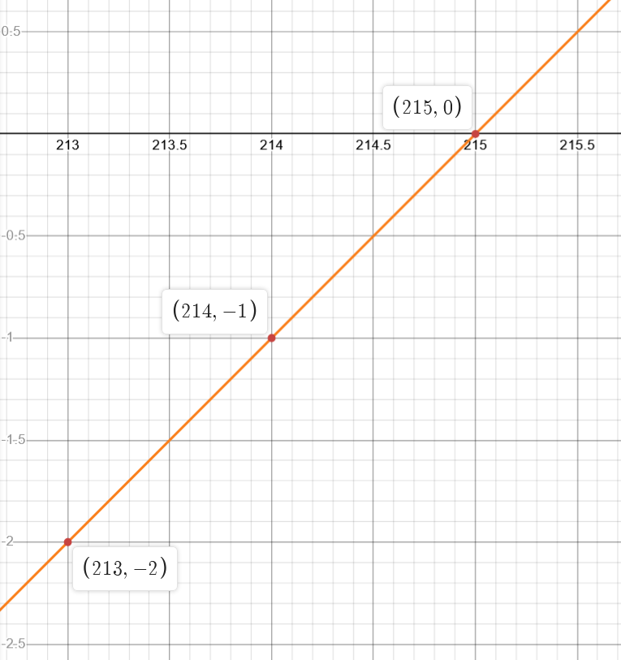

b) If g′(t) is positive for all t, we can conclude that g(214) > g(17).

True. Since g'(t) is positive for all t, g(t) can only increase as t increases. Thus, g(214) should be greater than g(17) if g'(t) is positive.

c) Bill and Samantha are driving separate cars in the same direction along the same road. At the start Samantha is 1 mile in front of Bill. If their speeds are the same at every moment thereafter, at the end of 20 minutes Samantha will be 1 mile in front of Bill.

True.

The speed of a moving object is given as change in distance over change in time, or:

speed = ∆ distance / ∆ time

Alternatively, by algebra, we can say that:

∆ distance = ∆ time * speed

Since their speeds are the same at every moment thereafter, and the time measured is the same (20 minutes), the distance between Bill and Samantha will remain the same.

d) Bill and Samantha are driving separate cars in the same direction along the same road. They start from the same point at 10 am and arrive at the same destination at 2 pm the same afternoon. At some time during the four hours their speeds must have been exactly the same.

True.

Given the relationship:

speed = ∆ distance / ∆ time

Since they both start at the same point and arrive at the same point, then ∆ distance is equal for Bill and Samantha. Similarly, they both depart at 10 am and arrive at 2 pm, thus, then ∆ time is the same.

Thus, their speed must have been exactly the same time at some point.

The important things to note here are:

- assuming both Bill and Samantha's vehicles begin at rest, and end at rest, we can say that initial speed and final speed will be zero at arrival and departure.
- car travel is contiguous, meaning along the total distance, travel proceeds continously without a break.

If we were to graph their speed over time, it would intersect at at least one point in time:

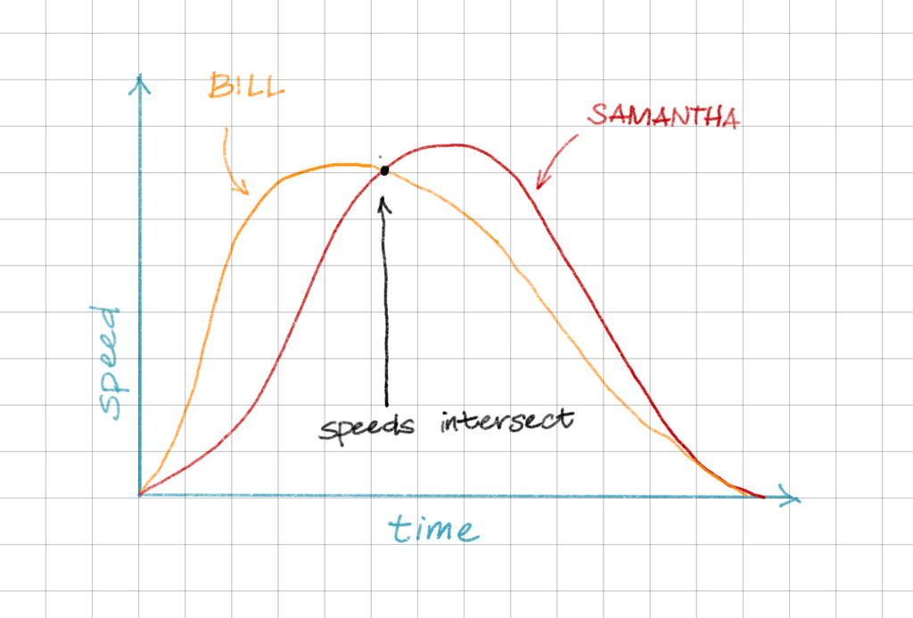

3. no. 2 (a,b,c,d) p. 131 - use code if you like.

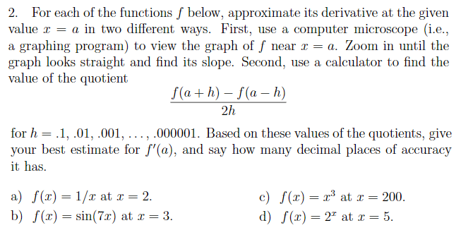

In order to calculate the estimates, we write the following code to display estimates for the value of the quotient for h = [.1, .01, .001, ..., 0.000001] for a given function.

```python
def find_quotient(func, a, h):
    y = (func(a + h) - func(a - h)) / (2 * h)
    return y

def print_quotients(func, a):
    from tabulate import tabulate
    h_vals = [0.1, 0.01, 0.001, 0.0001, 0.00001, 0.000001]
    quotients = [(h, find_quotient(func, a, h)) for h in h_vals]
    headers_=["h","quotient"]
    print(tabulate(quotients, headers=headers_, colalign=("left","left")))
```

a. f(x) = 1/x at x = 2

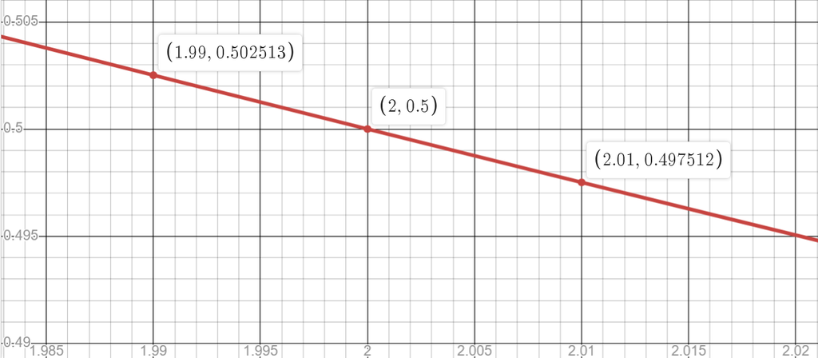

We zoom until the graph looks straight with a window of (∆x = 0.02). We can estimate the slope from the graph above:

= ∆y / ∆x

= (.497512 - 0.502513) / (2.01 - 1.99)

= (-0.005001) / (0.02)

= -0.25005

Now, we can call our print_quotients function to display estimates for the value of the quotient for h = [.1, .01, .001, ..., 0.000001]:

```python
def inverse(x):
    y = 1 / x
    return y

print_quotients(inverse, 2)
```

```
h       quotient
------  ----------
0.1     -0.250627
0.01    -0.250006
0.001   -0.25
0.0001  -0.25
1e-05   -0.25
1e-06   -0.25
```

Based on the values of the quotients, it looks like our best estimate for f'(a) is -0.25 with 2 decimal places of accuracy.

b. f(x) = sin(7x) at x = 3

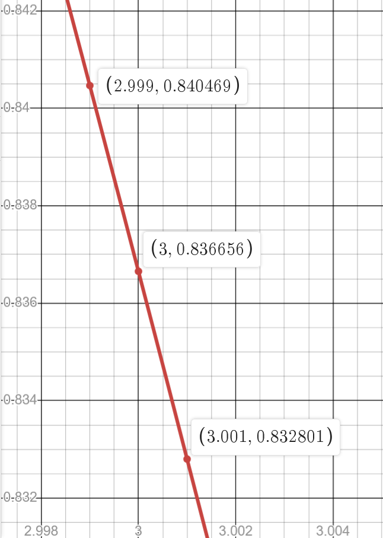

We zoom until the graph looks straight with a window of (∆x = 0.002). We can estimate the slope from the graph above:

= ∆y / ∆x

= (.832801 - 0.840469) / (2.001 - 1.999)

= (-0.007668) / (0.002)

= -3.834

```python
import numpy as np
def sin_x(x):
    y = np.sin(7*x)
    return y

print_quotients(sin_x, 3)
```

```
h       quotient
------  ----------
0.1     -3.52857
0.01    -3.83097
0.001   -3.83407
0.0001  -3.8341
1e-05   -3.8341
1e-06   -3.8341
```

Based on the values of the quotients, it looks like our best estimate for f'(a) is -3.8341 with 4 decimal places of accuracy.

c. f(x) = x^3 at x = 200

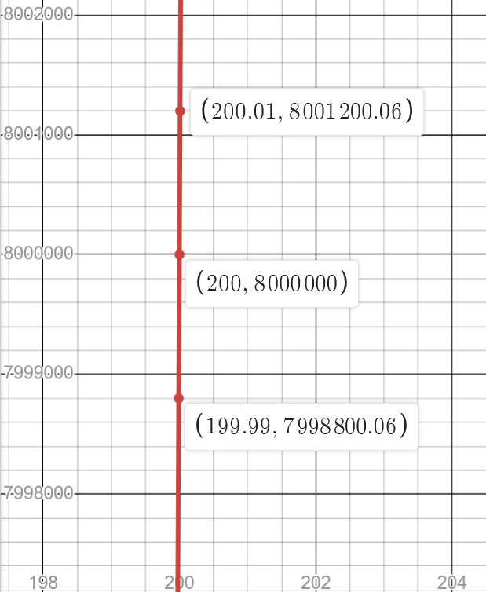

For this graph, we had to adjust the y-parameters until the graph is visible since the y-values are extremely high. For the slope estimate, we use a window of (∆x = 0.02).

We can estimate the slope from the graph above:

= ∆y / ∆x

= (8001200.06 - 7998800.06) / (200.01 - 199.99)

= (2400) / (0.02)

= 120,000

```python
def x_cubed(x):
    y = x ** 3
    return y

print_quotients(x_cubed, 200)
```

```
h       quotient
------  ----------
0.1     120000
0.01    120000
0.001   120000
0.0001  120000
1e-05   120000
1e-06   120000
```

The quotient valuse diverge to 120,000 starting from the lowest value of 'h'. It looks like our best estimate for f'(a) is 120,000.

d. f(x) = 2^x at x = 5

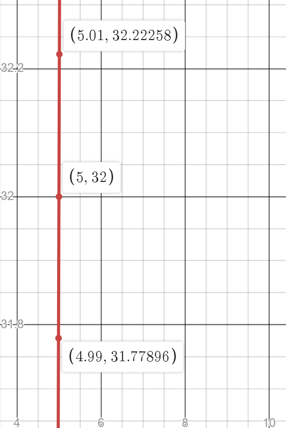

We zoom until the graph looks straight with a window of (∆x = 0.02). We can estimate the slope from the graph above:

= ∆y / ∆x

= (32.22258 - 31.77896) / (2.01 - 1.99)

= (0.44362) / (0.02)

= 22.181

```python
def two_exp(x):
    y = 2 ** x
    return y

print_quotients(two_exp, 5)
```

```
h       quotient
------  ----------
0.1     22.1985
0.01    22.1809
0.001   22.1807
0.0001  22.1807
1e-05   22.1807
1e-06   22.1807
```

Based on the values of the quotients, it looks like our best estimate for f'(a) is 22.1807 with 4 decimal places of accuracy.

**For the following activity (#4, p131), please add part d) below to your answer.**

4. no. 3, use code. P131 (use Python - following the pseudocode given - to write code to solve)

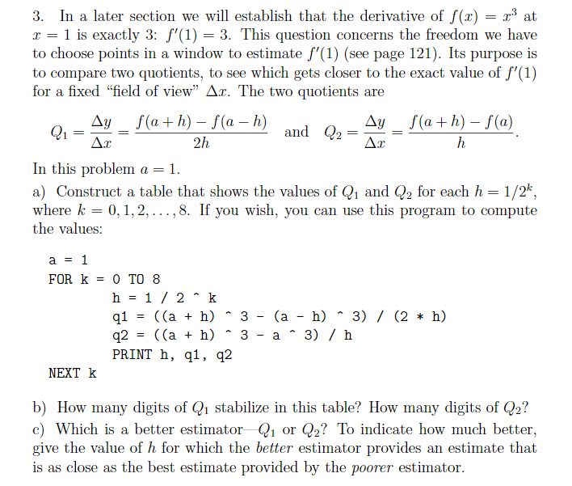

a. We write the following code to compute Q1 and Q2 for each h.

```python
def find_quotients(a):
    from tabulate import tabulate
    quotients = []
    for k in range(9):
        h = (1/2)**k
        q1 = (((a + h)**3 - (a - h)**3) / (2*h))
        q2 = (((a + h)**3 - a**3) / h)
        quotients.extend([(h, q1, q2)])
    headers_=["h","Q1","Q2"]
    print(tabulate(quotients, headers=headers_, colalign=("left","left","left")))

# a = 1
find_quotients(1)
```

```
h           Q1       Q2
----------  -------  -------
1           4        7
0.5         3.25     4.75
0.25        3.0625   3.8125
0.125       3.01562  3.39062
0.0625      3.00391  3.19141
0.03125     3.00098  3.09473
0.015625    3.00024  3.04712
0.0078125   3.00006  3.0235
0.00390625  3.00002  3.01173
```

c. Q1 seems to be the better estimator compared to Q2.

Looking at the table, Q1 starts to stabilize around h = 0.0625 whereas Q2 doesn't stabilize until h gets much much lower (until h = (0.5)**8).

Thus, h = 0.0625 seems to be the value for h for which the better estimator (Q1) provides an estimate that is as close as the best estimate provided by the poorer estimator (Q2).

d) Create either a hand drawn graph or use code to graph the 2 different slope formulas. What visual clues do we see that explains why one estimate is so much better than another?

We write the following code to graph the 2 different slope formulas:

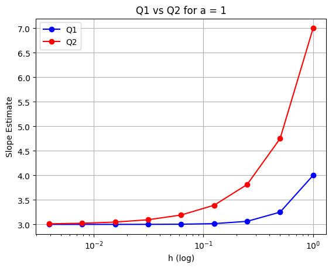

```python
def graph_quotients(a):
    import matplotlib.pyplot as plt
    h_ = []
    q1_ = []
    q2_ = []
    for k in range(9):
        h = (1/2)**k
        q1 = (((a + h)**3 - (a - h)**3) / (2*h))
        q2 = (((a + h)**3 - a**3) / h)
        h_.append(h)
        q1_.append(q1)
        q2_.append(q2)

    # plot values
    plt.plot(h_, q1_, label="Q1", marker='o', color = 'blue')
    plt.plot(h_, q2_, label="Q2", marker='o', color = 'red')

    plt.xscale("log")
    plt.xlabel("h (log)")
    plt.ylabel("Slope Estimate")

    plt.title(f"Q1 vs Q2 for a = {a}")
    plt.grid(True)
    plt.legend()
    plt.show()

graph_quotients(1)
```

Looking at the plot above, Q1 reaches stabilization much "faster" or at larger 'h' values compared to Q2, which is the strongest visual cueue we have that indicates that Q1 is a much better predictor than Q2. This means that Q1 can be performant even at "larger" window sizes of ∆x, compared to Q2.

5. no. 4, use code p.131

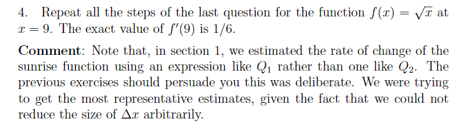

We use the same functions as in the previous section, adjusting the functions for Q1 and Q2 while doing so.

```python
def find_quotients(a):
    import numpy as np
    from tabulate import tabulate
    quotients = []
    for k in range(9):
        h = (1/2)**k
        q1 = (np.sqrt((a + h)) - np.sqrt((a - h))) / (2 * h)
        q2 = (np.sqrt((a + h)) - np.sqrt(a)) / h
        quotients.extend([(h, q1, q2)])
    headers_=["h","Q1","Q2"]
    print(tabulate(quotients, headers=headers_, colalign=("left","left","left")))

# a = 1
find_quotients(9)
```

```
h           Q1        Q2
----------  --------  --------
1           0.166925  0.162278
0.5         0.166731  0.164414
0.25        0.166683  0.165525
0.125       0.166671  0.166092
0.0625      0.166668  0.166378
0.03125     0.166667  0.166522
0.015625    0.166667  0.166594
0.0078125   0.166667  0.166631
0.00390625  0.166667  0.166649
```

Looking at the values of these quotients, Q1 starts to stabilize around h = 0.125 whereas Q2 does not start to stabilize until h = 0.0078125.

From the table above, it looks like up to 6 digits of Q1 stabilize, whereas only 4 digits of Q2 stabilize.

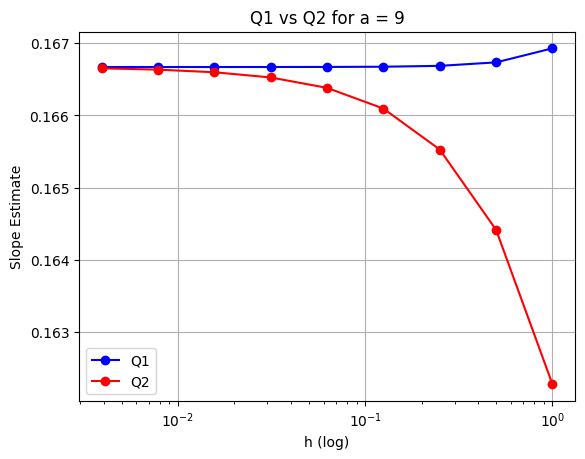

```python
def graph_quotients(a):
    import numpy as np
    import matplotlib.pyplot as plt
    h_ = []
    q1_ = []
    q2_ = []
    for k in range(9):
        h = (1/2)**k
        q1 = (np.sqrt((a + h)) - np.sqrt((a - h))) / (2 * h)
        q2 = (np.sqrt((a + h)) - np.sqrt(a)) / h
        h_.append(h)
        q1_.append(q1)
        q2_.append(q2)

    # plot values
    plt.plot(h_, q1_, label="Q1", marker='o', color = 'blue')
    plt.plot(h_, q2_, label="Q2", marker='o', color = 'red')

    plt.xscale("log")
    plt.xlabel("h (log)")
    plt.ylabel("Slope Estimate")

    plt.title(f"Q1 vs Q2 for a = {a}")
    plt.grid(True)
    plt.legend()
    plt.show()

graph_quotients(9)
```

We can clearly observe from the graph that Q1 is a much better estimator than Q2. The biggest visual indicator is that Q2 requires a much smaller value of 'h' to stabilize, whereas Q1 stabilize almost immediately even at relatively larger values of 'h'.

This also shows that Q1 is increasingly accurate without requiring an extremely small window size of ∆x.

6. no. 6, p.132

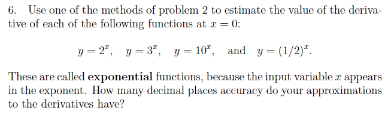

```python
def find_quotient(func, a, h):
    y = (func(a + h) - func(a - h)) / (2 * h)
    return y

def print_quotients(func, a):
    from tabulate import tabulate
    h_vals = [0.1, 0.01, 0.001, 0.0001, 0.00001, 0.000001]
    quotients = [(h, find_quotient(func, a, h)) for h in h_vals]
    headers_=["h","quotient"]
    print(tabulate(quotients, headers=headers_, colalign=("left","left")))
```

```python
def func_1(x):
    y = 2 ** x
    return y

def func_2(x):
    y = 3 ** x
    return y

def func_3(x):
    y = 10 ** x
    return y

def func_4(x):
    y = (1/2) ** x
    return y
```

- y = 2 ^ x

```python
# y = 2 ** x
print_quotients(func_1, 0)
```

```
h       quotient
------  ----------
0.1     0.693702
0.01    0.693153
0.001   0.693147
0.0001  0.693147
1e-05   0.693147
1e-06   0.693147
```

- y = 3 ^ x

```python
# y = 3 ** x
print_quotients(func_2, 0)
```

```
h       quotient
------  ----------
0.1     1.10082
0.01    1.09863
0.001   1.09861
0.0001  1.09861
1e-05   1.09861
1e-06   1.09861
```

- y = 10 ^ x

```python
# y = 10 ** x
print_quotients(func_3, 0)
```

```
h       quotient
------  ----------
0.1     2.32299
0.01    2.30279
0.001   2.30259
0.0001  2.30259
1e-05   2.30259
1e-06   2.30259
```

- y = (1/2) ^ x

```python
# y = (1/2) ** x
print_quotients(func_4, 0)
```

```
h       quotient
------  ----------
0.1     -0.693702
0.01    -0.693153
0.001   -0.693147
0.0001  -0.693147
1e-05   -0.693147
1e-06   -0.693147
```

Per the above tables, our approximations to the derivative consistently approach 6 decimal places of accuracy right around h = 0.001.

Despite the variance in functions, our estimates consistently approach this level of accuracy without requiring extremely small values of 'h'.

7. no. 15 p.134

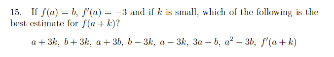

Following the diagram given in p. 121, we sketch out what the slope would look like for our given problem:

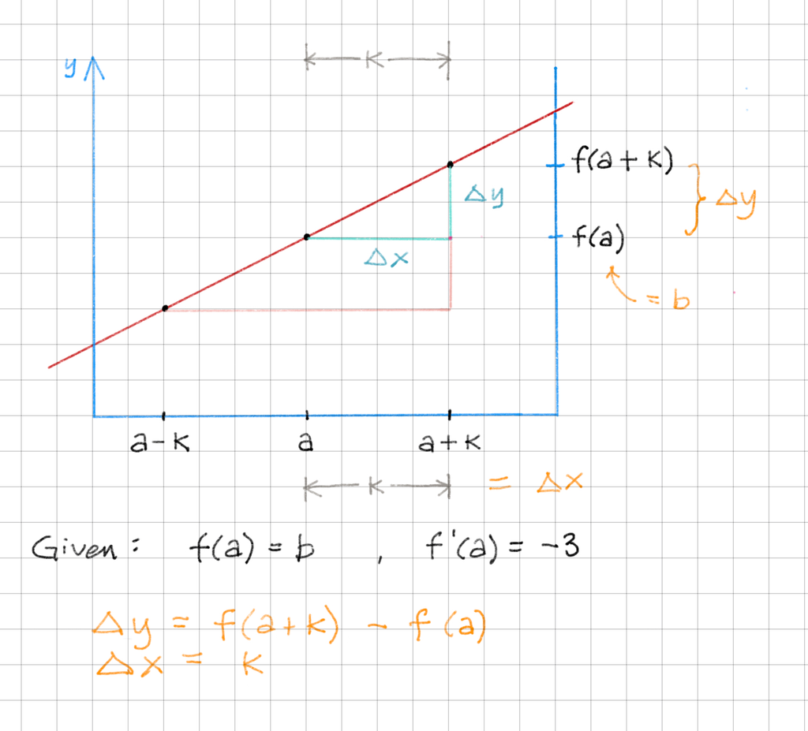

At the end of Ch. 3, the summary provides us the following:

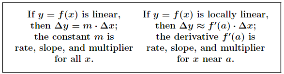

Since b is a constant, we can assume that in the k-sized window we are looking (k being small) that y = f(x) is locally linear.

Thus, if we can say:

∆y = f'(a) * ∆x

And from our diagram, we can measure that ∆y = f(a+k) - f(a), and ∆x is simply k. Thus,

∆y = f'(a) * ∆x

f(a+k) - f(a) = f'(a) * k

We are given: f(a) = b, f'(a) = −3, thus we substitute:

f(a+k) - f(a) = f'(a) * k

f(a+k) - b = -3 * k

Adding b to both sides:

**f(a+k) = b - 3 * k**

- Thus, from the given choices, we can say that **b - 3k** gives us the best estimate for **f(a+k)**.
8. no. 16 p134

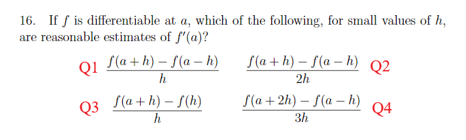

In order to examine this question, we wrote the functions below to allow us to evaluate what the above estimates would look like for different functions.

To make it easier to track our different quotients, we assign the names 'Q1, Q2, Q3, Q4' to each of the estimates.

**Q2** is also known as the difference quotient (p.120).

```python
def find_Q1(func, a, h):
    estimate = (func(a + h) - func(a - h)) / (h)
    return estimate

def find_Q2(func, a, h):
    estimate = (func(a + h) - func(a - h)) / (2 * h)
    return estimate

def find_Q3(func, a, h):
    estimate = (func(a + h) - func(h)) / (h)
    return estimate

def find_Q4(func, a, h):
    estimate = (func(a + 2 * h) - func(a - h)) / (3 * h)
    return estimate

# function_description is used to generate plot title
# include_plot takes a list of which estimates to graph, use [1,2,3,4] to plot all four
def graph_quotients(a, func, function_description, include_plots):
    from tabulate import tabulate
    import matplotlib.pyplot as plt
    h_ = []
    q1_ = []
    q2_ = []
    q3_ = []
    q4_ = []
    for k in range(3,10):
        h = (1/2) ** k
        q1 = find_Q1(func, a, h)
        q2 = find_Q2(func, a, h)
        q3 = find_Q3(func, a, h)
        q4 = find_Q4(func, a, h)
        h_.append(h)
        q1_.append(q1)
        q2_.append(q2)
        q3_.append(q3)
        q4_.append(q4)

    # only graph plots in include_plot list
    if 1 in include_plots:
        plt.plot(h_, q1_, label="Q1", marker='o', color = 'blue')
    if 2 in include_plots:
        plt.plot(h_, q2_, label="Q2", marker='o', color = 'red')
    if 3 in include_plots:
        plt.plot(h_, q3_, label="Q3", marker='o', color = 'orange')
    if 4 in include_plots:
        plt.plot(h_, q4_, label="Q4", marker='o', color = 'green')

    plt.xscale("log")
    plt.xlabel("h (log)")
    plt.ylabel("Slope Estimate")

    ax = plt.gca()
    #ax.set_ylim([3 , 6])

    plt.title(f"{function_description} at a = {a}")
    plt.grid(True)
    plt.legend()
    plt.show()

    # tabulate results
    print(tabulate({"h": h_, "Q1": q1_, "Q2": q2_, "Q3": q3_, "Q4": q4_}, headers = "keys"))
```

We also define the following sample functions from the previous sections to examine with our graphing function:

```python
def x_cubed(x):
    y = x ** 3
    return y

def x_squared(x):
    y = x ** 2
    return y

def sin_x(x):
    import numpy as np
    y = np.sin(7*x)
    return y

def two_exp(x):
    y = 2 ** x
    return y
```

Now let's examine how our estimates perform over different functions.

Let's start by looking at our estimates for the function y = x ^ 2:

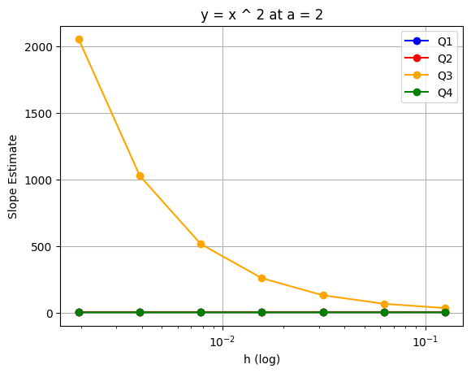

```
         h    Q1    Q2    Q3       Q4
----------  ----  ----  ----  -------
0.125          8     4    36  4.125
0.0625         8     4    68  4.0625
0.03125        8     4   132  4.03125
0.015625       8     4   260  4.01562
0.0078125      8     4   516  4.00781
0.00390625     8     4  1028  4.00391
0.00195312     8     4  2052  4.00195
```

```python
graph_quotients(2, x_squared, "y = x ^ 2", [1,2,3,4])
```

Q3 looks way off.

Q2 and Q4 seem to stabilize nicely, and Q1 appears to be double Q2's and Q4's values.

For additional confirmation, let's look at our estimates for the function y = x ^ 3:

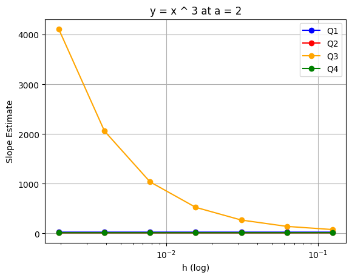

```
         h       Q1       Q2        Q3       Q4
----------  -------  -------  --------  -------
0.125       24.0312  12.0156    76.75   12.7969
0.0625      24.0078  12.0039   140.375  12.3867
0.03125     24.002   12.001    268.188  12.1904
0.015625    24.0005  12.0002   524.094  12.0945
0.0078125   24.0001  12.0001  1036.05   12.0471
0.00390625  24       12       2060.02   12.0235
0.00195312  24       12       4108.01   12.0117
```

```python
graph_quotients(2, x_cubed, "y = x ^ 3", [1,2,3,4])
```

From the two sets of data above, it looks like we can rule out Q3 as being a good estimate. The tabulated data also shows Q1 as being off by a factor of 2.

Let's exclude Q3 from the plot and confirm:

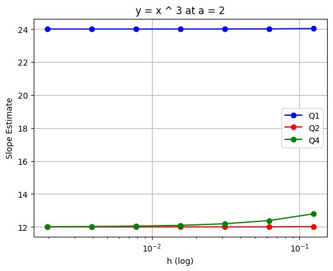

```
         h       Q1       Q2        Q3       Q4
----------  -------  -------  --------  -------
0.125       24.0312  12.0156    76.75   12.7969
0.0625      24.0078  12.0039   140.375  12.3867
0.03125     24.002   12.001    268.188  12.1904
0.015625    24.0005  12.0002   524.094  12.0945
0.0078125   24.0001  12.0001  1036.05   12.0471
0.00390625  24       12       2060.02   12.0235
0.00195312  24       12       4108.01   12.0117
```

```python
graph_quotients(2, x_cubed, "y = x ^ 3", [1,2,4])
```

It certainly looks like we can also conclude that Q1 is not a viable estimate.

Now, we are down to Q2 and Q4. Let's take a closer look at how these two estimates compare.

[figure not shown]

```
         h       Q1        Q2          Q3         Q4
----------  -------  --------  ----------  ---------
0.125       1.67923  0.839614   -0.220924  -1.52546
0.0625      1.85383  0.926917    8.50499   -0.530376
0.03125     1.89909  0.949545   24.9493     0.191047
0.015625    1.91051  0.955253   56.9892     0.574118
0.0078125   1.91337  0.956683  120.568      0.766358
0.00390625  1.91408  0.957041  247.459      0.862028
0.00195312  1.91426  0.957131  501.101      0.909673
```

```python
# exclude Q1 and Q3 from plot
graph_quotients(2, sin_x, "y = sin(x)", [2,4])
```

In the above table, Q2 stabilizes to 2 digits whereas Q4 approaches Q2's values but does not really stabilize.

Now, let's compare Q2 and Q4 over the function y = 2 ^ x:

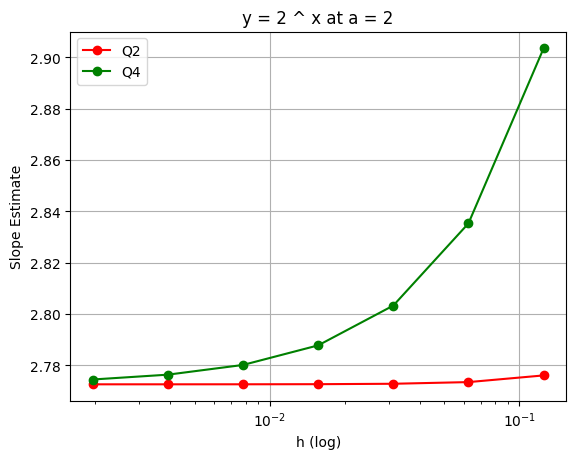

```
         h       Q1       Q2         Q3       Q4
----------  -------  -------  ---------  -------
0.125       5.55212  2.77606    26.1722  2.9035
0.0625      5.54691  2.77346    50.1251  2.83529
0.03125     5.54561  2.77281    98.1021  2.80327
0.015625    5.54529  2.77264   194.091   2.78777
0.0078125   5.5452   2.7726    386.085   2.78014
0.00390625  5.54518  2.77259   770.082   2.77635
0.00195312  5.54518  2.77259  1538.08    2.77447
```

```python
# exclude Q1 and Q3 from plot
graph_quotients(2, two_exp, "y = 2 ^ x", [2,4])
```

From the above table, Q2 appears significantly more performant than Q4.

Q2 starts to stabilize to 3 digits at h = 0.03125, and eventually to 5 digits. Whereas Q4 only stabilizes to 2 digits at the smallest h-values.

**Conclusion**

From our analysis, we can say that the estimate given by Q2, also known as the **difference quotient**, affords us the best estimate of f'(a) from the options given. :

However, since the questions asks "which of the following, for small values of h, are **reasonable estimates** of f'(a)", we can say that both Q2 and Q4 both offer reasonable estimates of f'(a):